# Practical Pandas, Matplotlib and Seaborn Training

### 5.15 Pair plot

**Line by line:**

- `sns.pairplot(data=df, vars=[...], hue=)` builds a full grid of scatter plots for every pair of chosen numeric variables, with histograms (or KDEs) on the diagonal - a fast way to scan several relationships and distributions at once, split by a category colour.

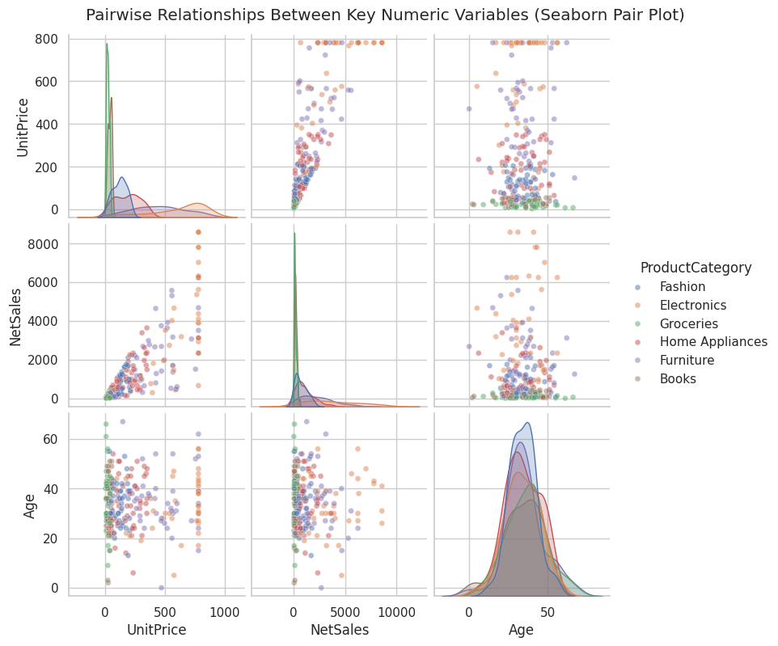

```python
pair_sample = plot_df.dropna(subset=['UnitPrice', 'NetSales', 'Age', 'Rating']).sample(
    n=min(250, len(plot_df)), random_state=3)

g = sns.pairplot(pair_sample, vars=['UnitPrice', 'NetSales', 'Age'], hue='ProductCategory',
                  diag_kind='kde', plot_kws={'alpha': 0.5, 's': 25}, height=2.6)
g.figure.suptitle('Pairwise Relationships Between Key Numeric Variables (Seaborn Pair Plot)', y=1.02)
plt.show()
```

### 5.16 Joint plot

**Line by line:**

- `sns.jointplot(data=df, x=, y=, kind=)` combines a central scatter (or hex-bin, or KDE) plot with the marginal distribution of each variable shown along the top and right edges - `kind` can be `'scatter'`, `'hex'`, `'kde'`, `'reg'`, among others.

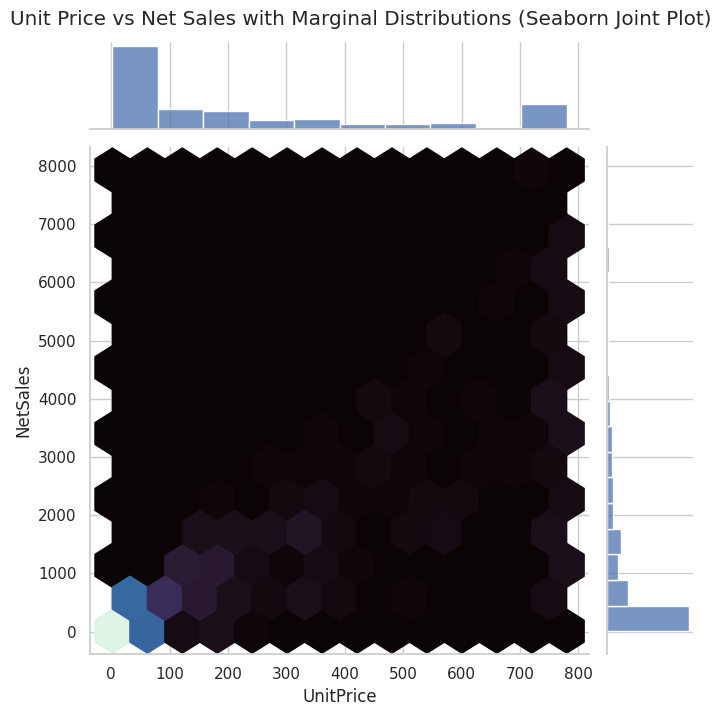

```python
g = sns.jointplot(data=sample, x='UnitPrice', y='NetSales', kind='hex', height=7, cmap='mako')
g.figure.suptitle('Unit Price vs Net Sales with Marginal Distributions (Seaborn Joint Plot)', y=1.02)
plt.show()
```

### 5.17 Cat plot (figure-level categorical plotting)

**Line by line:**

- `sns.catplot(data=df, x=, y=, kind=, col=)` is a figure-level function that can produce any of Seaborn's categorical plot types (`'bar'`, `'box'`, `'violin'`, `'strip'`, `'swarm'`, `'point'`) and automatically split them into a grid of small multiples using `col=` or `row=`.

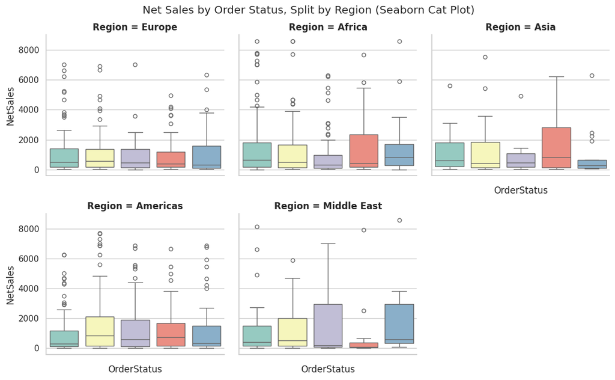

```python
g = sns.catplot(data=plot_df, x='OrderStatus', y='NetSales', kind='box', col='Region',
                 col_wrap=3, height=3.5, aspect=1.1, palette='Set3',
                 order=plot_df['OrderStatus'].value_counts().index)
g.figure.suptitle('Net Sales by Order Status, Split by Region (Seaborn Cat Plot)', y=1.02)
g.set_xticklabels(rotation=30)
plt.show()
```

### 5.18 Point plot

**Line by line:**

- `sns.pointplot(data=df, x=, y=, hue=)` plots the mean of `y` for each category as a point, connected by a line, with an error bar - useful for comparing trends across an ordered category, such as spotting which day of the week performs best.

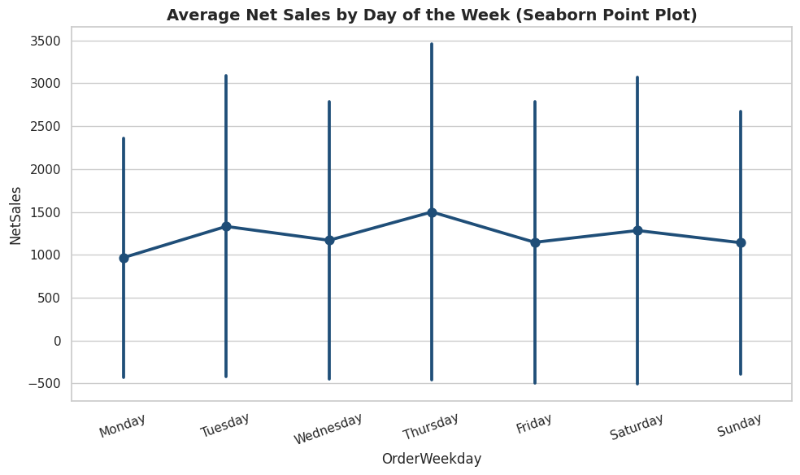

```python
weekday_order = ['Monday','Tuesday','Wednesday','Thursday','Friday','Saturday','Sunday']
fig, ax = plt.subplots(figsize=(10, 6))
sns.pointplot(data=plot_df, x='OrderWeekday', y='NetSales', order=weekday_order,
              errorbar='sd', color='#1F4E78', ax=ax)
ax.set_title('Average Net Sales by Day of the Week (Seaborn Point Plot)')
plt.xticks(rotation=20)
fig.tight_layout()
plt.show()
```

### 5.19 Facet grid

**Line by line:**

- `sns.FacetGrid(data, col=, row=)` builds an empty grid of small charts split by one or two categorical variables.
- `.map_dataframe(plotting_function, x=, y=)` draws the same chart type into every cell of the grid.
- `.add_legend()` adds one shared legend for the whole grid.

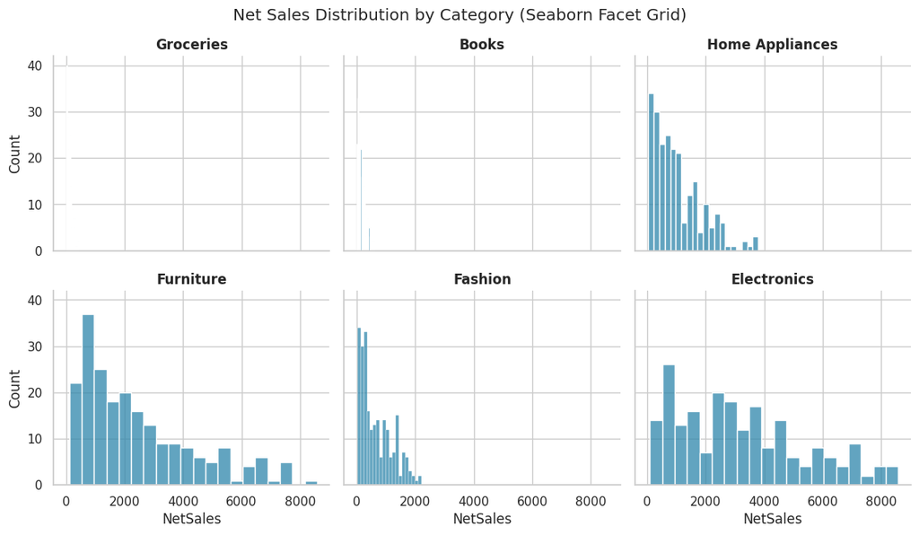

```python
g = sns.FacetGrid(plot_df, col='ProductCategory', col_wrap=3, height=3.2, aspect=1.2)
g.map_dataframe(sns.histplot, x='NetSales', bins=20, color='#2E86AB')
g.set_titles(col_template='{col_name}')
g.figure.suptitle('Net Sales Distribution by Category (Seaborn Facet Grid)', y=1.03)
plt.show()
```

### 5.20 Styling: themes, palettes and context

**Line by line:**

- `sns.set_theme(style=, palette=)` (used at the very top of the notebook) sets the default look for every chart drawn afterwards - `style` controls the background grid (`'whitegrid'`, `'darkgrid'`, `'white'`, `'dark'`, `'ticks'`), `palette` controls the default colour sequence.
- `sns.set_context('talk')` scales up font sizes and line widths for presentation use, versus `'paper'` for compact, print-ready figures.
- These calls affect every subsequent chart, so they are normally set once, near the top of a notebook or script - demonstrated here on one chart, then reset back to the notebook default.

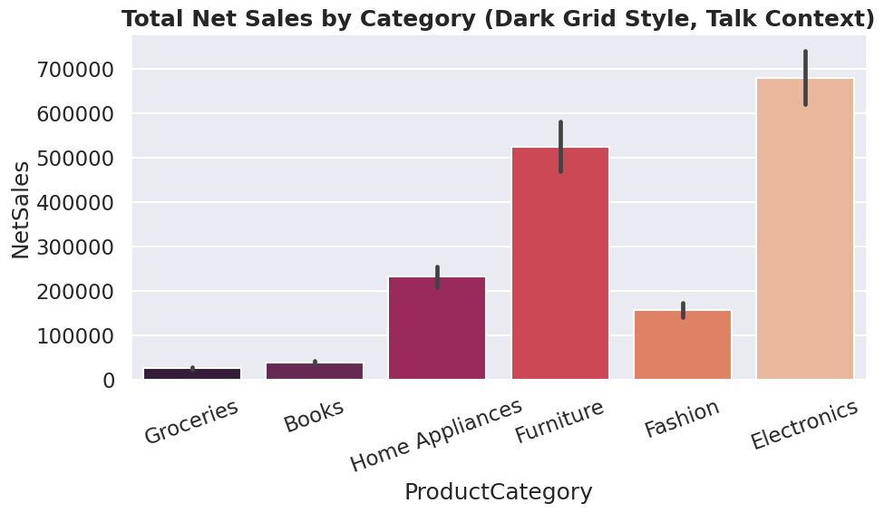

```python
with sns.axes_style('darkgrid'), sns.plotting_context('talk'):
    fig, ax = plt.subplots(figsize=(10, 6))
    sns.barplot(data=plot_df, x='ProductCategory', y='NetSales', estimator='sum',
                hue='ProductCategory', legend=False, palette='rocket', ax=ax)
    ax.set_title('Total Net Sales by Category (Dark Grid Style, Talk Context)')
    plt.xticks(rotation=20)
    fig.tight_layout()
    plt.show()

sns.set_theme(style='whitegrid', palette='deep')  # restore the notebook default
```

# PART 6 - Bringing It Together: A Mini Dashboard

A short closing example that combines several of the techniques from this notebook - grouping, pivoting, and a multi-panel Matplotlib and Seaborn figure - into one summary view, the kind of output a training session usually ends on.

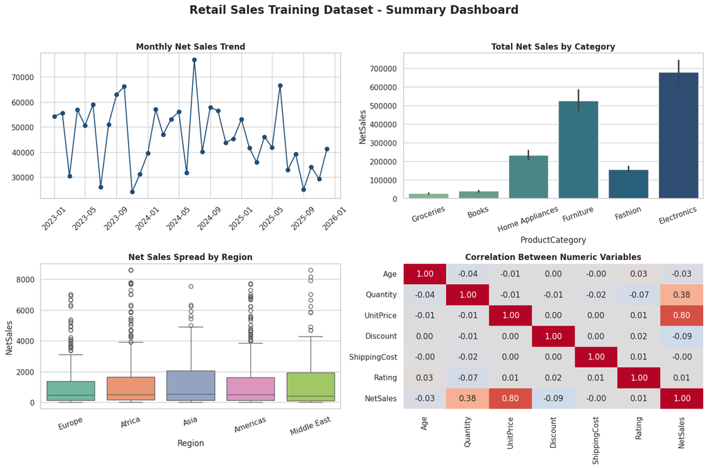

```python
fig = plt.figure(figsize=(15, 10))
gs = fig.add_gridspec(2, 2)

ax1 = fig.add_subplot(gs[0, 0])
ax1.plot(monthly_sales_plot.index, monthly_sales_plot.values, color='#1F4E78', marker='o')
ax1.set_title('Monthly Net Sales Trend')
ax1.tick_params(axis='x', rotation=45)

ax2 = fig.add_subplot(gs[0, 1])
sns.barplot(data=plot_df, x='ProductCategory', y='NetSales', estimator='sum',
            hue='ProductCategory', legend=False, palette='crest', ax=ax2)
ax2.set_title('Total Net Sales by Category')
ax2.tick_params(axis='x', rotation=20)

ax3 = fig.add_subplot(gs[1, 0])
sns.boxplot(data=plot_df, x='Region', y='NetSales', hue='Region', legend=False, palette='Set2', ax=ax3)
ax3.set_title('Net Sales Spread by Region')
ax3.tick_params(axis='x', rotation=20)

ax4 = fig.add_subplot(gs[1, 1])
sns.heatmap(corr_matrix, annot=True, fmt='.2f', cmap='coolwarm', center=0, ax=ax4, cbar=False)
ax4.set_title('Correlation Between Numeric Variables')

fig.suptitle('Retail Sales Training Dataset - Summary Dashboard', fontsize=17, fontweight='bold')
fig.tight_layout(rect=[0, 0, 1, 0.96])
fig.savefig('dashboard_summary.png', dpi=200, bbox_inches='tight')
plt.show()
```

## Course Summary

**Data cleaning covered:** missing values (`dropna`, `fillna`, forward/backward fill, interpolation), duplicate removal (exact and key-based), data type conversion (`astype`, `pd.to_numeric`, `pd.to_datetime`), text cleaning (`str.strip`, `str.lower/upper/title`, `str.replace`, `str.contains`, `str.extract`, `str.split`), categorical standardisation with mapping dictionaries and `np.where`, outlier handling (IQR method, domain-rule cleaning, `clip`), and column renaming and reordering.

**Data manipulation covered:** selection and filtering (`loc`, `iloc`, boolean indexing, `isin`, `between`, `query`), sorting (`sort_values`, `nlargest`, `nsmallest`), new columns (vectorised arithmetic, `apply`, `lambda`, `np.select`), `groupby` and aggregation (including named aggregation), `pivot_table` and `crosstab`, reshaping (`melt`, `pivot`, `stack`, `unstack`), merging and concatenation (`merge` with every join type, `concat`), binning (`cut`, `qcut`), ranking and cumulative statistics (`rank`, `cumsum`, `diff`, `pct_change`), time series tools (`resample`, `rolling`, the `.dt` accessor), MultiIndex operations, and `apply` / `map`.

**Matplotlib charts covered:** line, vertical bar, horizontal bar, stacked bar, grouped bar, histogram, box plot, scatter and bubble chart, pie chart, area chart, stacked area chart, step plot, stem plot, error bar plot, dual axis chart, multi-panel subplots, and saving a figure to file.

**Seaborn charts covered:** scatter plot, line plot, bar plot, count plot, box plot, violin plot, strip plot, swarm plot, histogram with KDE, KDE plot, ECDF plot, correlation heatmap, pivot-table heatmap, regression plot (`regplot` and `lmplot`), pair plot, joint plot, cat plot, point plot, facet grid, and theme / palette / context styling.

**Prepared by: Kajola Gbenga** **Data Scientist & AI Engineer**